# Modèle linéaire généralisé et choix de modèles

Devoir maison obligatoire (Dauphine)

Paul Hardouin

August 31, 2019

# 1. Introduction

#### **1.1 Données et objectif**

Pour cette étude, nous travaillons sur un jeu de données [source : **MeteoBlue**] sur les conditions météorologiques à Bale. Chaque ligne correspond à un jour entre 2010 et 2018. On y trouve les mesures de paramètres divers, ainsi qu’un booléen **pluie.demain** informant de la présence de pluie le lendemain du jour concerné.

#### **1.2 Type de modèle à trouver**

L’objectif est de trouver une valeur booléenne en fonction de covariables à valeurs continues.  
Il s’agit donc d’un problème de régréssion logistique.

Compte-tenu de la nature du problème, nous cherchons un modèle **LOGIT [glm, family = binomial]**  
On ne s’intéresse pas au probit, car la probabilité recherchée n’est pas très proche de 0 ou de 1.

Nous renoncons aux modèles suivants

- **PROBIT** [glm, family = binomial(link = “probit”)]
- **BINOMIAL** [glm + cbind, family = binomial]
- **MULTINOMIAL** [multinom]
- **CUMULATIF** [clm]
- **POISSON** [glm, family = poisson]

#### **1.3 Quatre méthodes pour trouver les modèles**

- **MANUEL** : sélection de covariables en observant les données
- **stepAIC** : recherche pas à pas en utilisant le critère AIC
- **stepBIC** : recherche pas à pas en utilisant le critère BIC
- **COMPLET** : utilisation de toutes les covariables

# 2. Lecture et exploration des données

#### **2.1 Lecture**

```r
d = read.csv("meteo.train.csv")
#summary(d)
```

#### **2.2 Visualisation des données**

On veut pouvoir observer facilement l’influence des covariables sur **pluie.demain**  
On crée donc la fonction **myVisu** pour cela

```r
  myVisu = function(d,ind,exportOption){
    # 0. Load library
      library(ggplot2)
      library(egg)
      p = ggplot(d, aes_string(x = colnames(d)[ind], fill = "pluie.demain"))
    # 1. Create histogramme
      p = ggplot(d, aes_string(x = colnames(d)[ind], fill = "pluie.demain"))
      hp = p + labs(title = colnames(d)[ind], x = colnames(d)[ind],  y = "Densité empirique",
                    fill = "Pluie Demain", subtitle = "Histogramme de distribution") +
              geom_density(alpha = 0.4) + # Transparency
              guides(fill = guide_legend(override.aes = list(alpha = 1)))
    # 2. Create a box plot (bp)
      p = ggplot(d, aes_string(x = "pluie.demain", y = colnames(d)[ind]))
      bp = p + geom_boxplot(aes_string(color = "pluie.demain"), alpha=0.5)
    # 3. Display
      figure = ggarrange(hp, bp, ncol = 2, nrow = 1)
    # 4. Export
      if (exportOption){ggsave(sprintf("meteo_feature_%02d.png",ind), plot = figure, width = 11, height = 8)}
    # 5. Update indice
      return(figure)
  }
```

```r
  # for(i in 1:ncol(d)){
  #   if(length(unique(d[, i])) >= 2 & colnames(d)[i] != "pluie.demain")
  #   {
  #     toto = myVisu(d,i,1)
  #   }
  # }
```

On observe des covariables qui semblent pouvoir influer **pluie.demain**  
En effet, les distributions **TRUE/FALSE** sont différentes.

```r
    library(gridExtra)
    #myFig=myVisu(d, 9,0)
    myFig=myVisu(d,12,0)
```

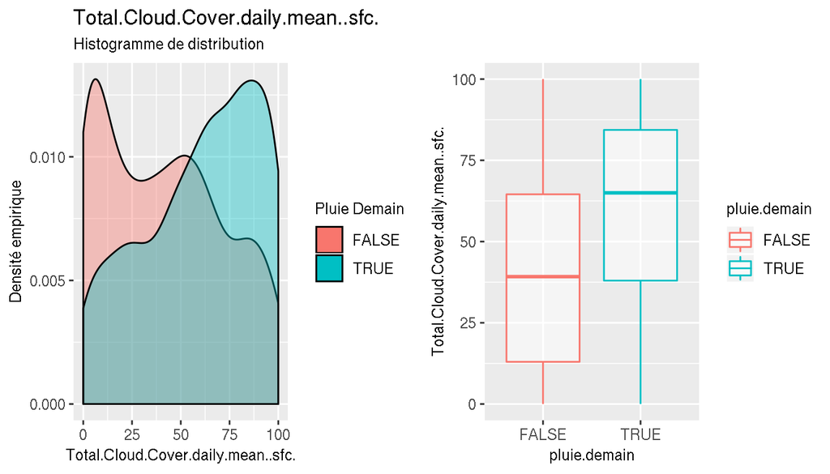

A l’inverse, on voit aussi des covariables pour lesquelles les distributions **TRUE/FALSE** sont très proches.

```r
    #myFig=myVisu(d, 8,0)
    myFig=myVisu(d,28,0)
```

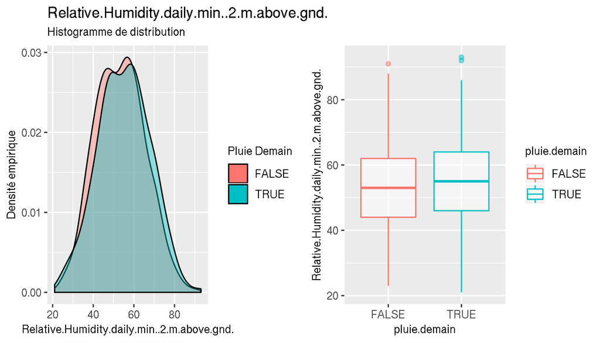

# 3. Ajout et suppression de covariables

#### **3.1 Ajout de covariables**

On sent intuitivement que le cycle des saisons peut avoir une influence sur la pluie.  
Pour appliquer une régréssion linéaire sur une telle information, on veut créer 2 covariables:

- le **cosinus** du **jour julien**
- le **sinus** du **jour julien**

On s’apercoit en réalite que la vraie périodicité est plutot de 6 mois.  
Les covariables créées sont donc les suivantes:

- la valeur absolue du **cosinus** du **jour julien**
- la valeur absolue du **sinus** du **jour julien**

```r
  tmp = do.call(paste, list(d$Month, d$Day, d$Year))
  tmp = as.Date(tmp, format=c("%m %d %Y"))
  d$mycosJD <- abs(cos(as.numeric(format(tmp, "%j"))/365*2*pi))
  d$mysinJD <- abs(sin(as.numeric(format(tmp, "%j"))/365*2*pi))
```

On visualise la distribution suivante pour **mycosJD**

```r
    myFig=myVisu(d,48,0)
```

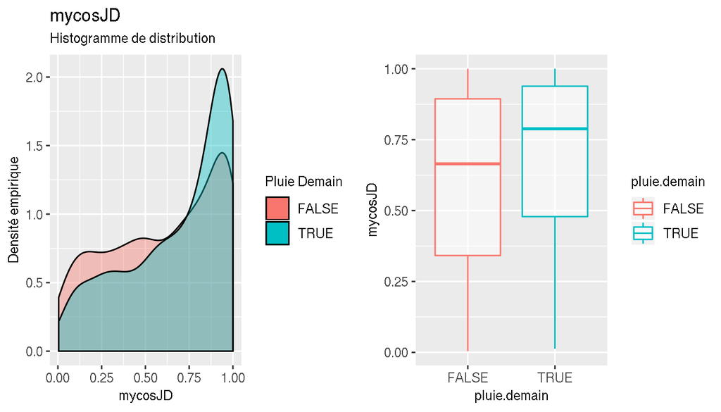

On visualise la distribution suivante pour **mysinJD**

```r
    myFig=myVisu(d,49,0)
```

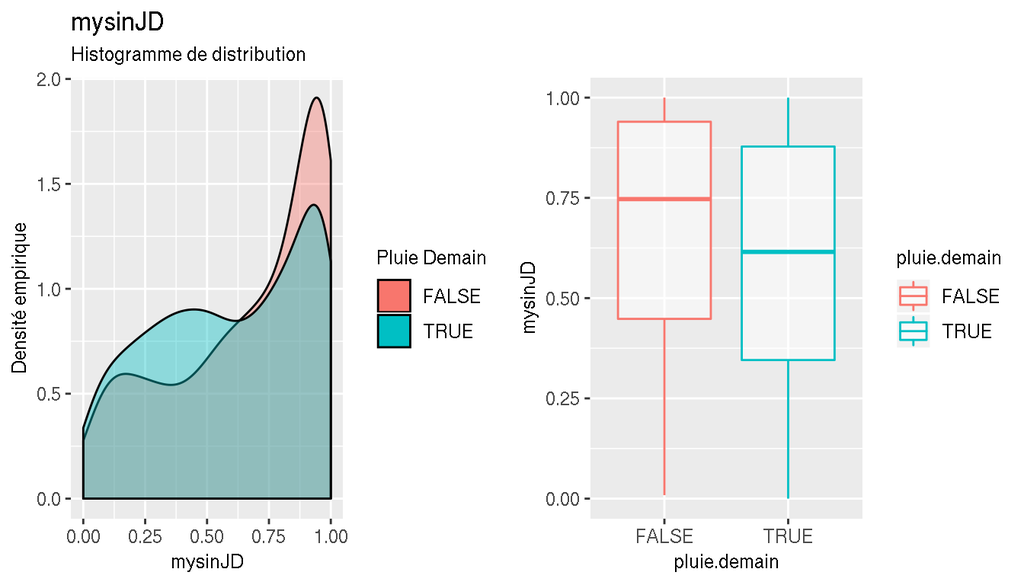

#### **3.2 Suppression de covariables inutiles**

On supprime quelques covariables encombrantes. Les **heures** et les **minutes**.

```r
  d = d[,!colnames(d) %in% c("Hour", "Minute")]
```

# 4. Construction des 4 modèles

#### **4.1 Modèle 1 : MANUEL : sélection de covariables en observant les données**

Pour ce modèle, on fait une selection manuelle des covariables. Pour cela, on exporte **myVisu** pour toutes les covariables vues en haut. On sélectionne alors manuellement les covariables aui nous intéressent.

On obtient un modèle avec 11 covariables.

```r
  m_perso = glm(formula = pluie.demain ~ Mean.Sea.Level.Pressure.daily.mean..MSL. +
                                          Mean.Sea.Level.Pressure.daily.max..MSL. +
                                          Mean.Sea.Level.Pressure.daily.min..MSL. +
                                          Total.Cloud.Cover.daily.mean..sfc. +
                                          Sunshine.Duration.daily.sum..sfc. +
                                          Wind.Direction.daily.mean..10.m.above.gnd. +
                                          Wind.Direction.daily.mean..80.m.above.gnd. +
                                          Wind.Direction.daily.mean..900.mb. +
                                          High.Cloud.Cover.daily.max..high.cld.lay. +
                                          mycosJD +
                                          mysinJD,
          family = binomial,
          data = d)
  f_perso= formula(m_perso) # formule du modèle
  n_perso = names(m_perso$coefficients) # nom des covariables retenues
  summary(m_perso)
```

```
##
## Call:
## glm(formula = pluie.demain ~ Mean.Sea.Level.Pressure.daily.mean..MSL. +
##     Mean.Sea.Level.Pressure.daily.max..MSL. + Mean.Sea.Level.Pressure.daily.min..MSL. +
##     Total.Cloud.Cover.daily.mean..sfc. + Sunshine.Duration.daily.sum..sfc. +
##     Wind.Direction.daily.mean..10.m.above.gnd. + Wind.Direction.daily.mean..80.m.above.gnd. +
##     Wind.Direction.daily.mean..900.mb. + High.Cloud.Cover.daily.max..high.cld.lay. +
##     mycosJD + mysinJD, family = binomial, data = d)
##
## Deviance Residuals:
##     Min       1Q   Median       3Q      Max
## -2.2670  -0.9134  -0.2571   0.9338   2.3929
##
## Coefficients:
##                                              Estimate Std. Error z value
## (Intercept)                                98.9140668 10.9297545   9.050
## Mean.Sea.Level.Pressure.daily.mean..MSL.    0.1880782  0.1135358   1.657
## Mean.Sea.Level.Pressure.daily.max..MSL.    -0.1391341  0.0627025  -2.219
## Mean.Sea.Level.Pressure.daily.min..MSL.    -0.1477216  0.0594406  -2.485
## Total.Cloud.Cover.daily.mean..sfc.          0.0042020  0.0057882   0.726
## Sunshine.Duration.daily.sum..sfc.          -0.0004445  0.0005938  -0.749
## Wind.Direction.daily.mean..10.m.above.gnd.  0.0040049  0.0048134   0.832
## Wind.Direction.daily.mean..80.m.above.gnd. -0.0063310  0.0050283  -1.259
## Wind.Direction.daily.mean..900.mb.          0.0055116  0.0011953   4.611
## High.Cloud.Cover.daily.max..high.cld.lay.   0.0076935  0.0017157   4.484
## mycosJD                                     0.7765446  0.5408170   1.436
## mysinJD                                    -0.3002482  0.5397814  -0.556
##                                            Pr(>|z|)
## (Intercept)                                 < 2e-16 ***
## Mean.Sea.Level.Pressure.daily.mean..MSL.     0.0976 .
## Mean.Sea.Level.Pressure.daily.max..MSL.      0.0265 *
## Mean.Sea.Level.Pressure.daily.min..MSL.      0.0129 *
## Total.Cloud.Cover.daily.mean..sfc.           0.4679
## Sunshine.Duration.daily.sum..sfc.            0.4541
## Wind.Direction.daily.mean..10.m.above.gnd.   0.4054
## Wind.Direction.daily.mean..80.m.above.gnd.   0.2080
## Wind.Direction.daily.mean..900.mb.         4.01e-06 ***
## High.Cloud.Cover.daily.max..high.cld.lay.  7.32e-06 ***
## mycosJD                                      0.1510
## mysinJD                                      0.5780
## ---
## Signif. codes:  0 '***' 0.001 '**' 0.01 '*' 0.05 '.' 0.1 ' ' 1
##
## (Dispersion parameter for binomial family taken to be 1)
##
##     Null deviance: 1724.5  on 1243  degrees of freedom
## Residual deviance: 1403.8  on 1232  degrees of freedom
## AIC: 1427.8
##
## Number of Fisher Scoring iterations: 4
```

#### **4.2 Modèle 2 : stepAIC : recherche pas à pas en utilisant le critère AIC**

Pour ce modèle, on fait une recherche pas à pas en utilisant le critère AIC (par defaut). On fait une recherche avec la méthode progressive.

```r
  fit1 = glm(pluie.demain ~ ., family = binomial, data = d)
  fit2 = glm(pluie.demain ~ 1, family = binomial, data = d)
  m_AIC = step(fit2,direction="both"    ,scope=list(upper=fit1,lower=fit2))
```

AIC : on obtient un modèle avec 9 covariables.

```r
  f_AIC = formula(m_AIC) # formule du modèle
  n_AIC = names(m_AIC$coefficients) # nom des covariables retenues
  summary(m_AIC)
```

```
##
## Call:
## glm(formula = pluie.demain ~ Mean.Sea.Level.Pressure.daily.min..MSL. +
##     Medium.Cloud.Cover.daily.max..mid.cld.lay. + mysinJD + Wind.Direction.daily.mean..900.mb. +
##     High.Cloud.Cover.daily.mean..high.cld.lay. + Mean.Sea.Level.Pressure.daily.max..MSL. +
##     Mean.Sea.Level.Pressure.daily.mean..MSL. + Total.Cloud.Cover.daily.max..sfc. +
##     Low.Cloud.Cover.daily.mean..low.cld.lay., family = binomial,
##     data = d)
##
## Deviance Residuals:
##     Min       1Q   Median       3Q      Max
## -2.1953  -0.9195  -0.2912   0.9264   2.3678
##
## Coefficients:
##                                              Estimate Std. Error z value
## (Intercept)                                92.9910621 10.5539094   8.811
## Mean.Sea.Level.Pressure.daily.min..MSL.    -0.1543399  0.0598128  -2.580
## Medium.Cloud.Cover.daily.max..mid.cld.lay.  0.0111587  0.0024315   4.589
## mysinJD                                    -0.9920768  0.2181659  -4.547
## Wind.Direction.daily.mean..900.mb.          0.0038405  0.0009557   4.019
## High.Cloud.Cover.daily.mean..high.cld.lay.  0.0104611  0.0036656   2.854
## Mean.Sea.Level.Pressure.daily.max..MSL.    -0.1444229  0.0620434  -2.328
## Mean.Sea.Level.Pressure.daily.mean..MSL.    0.2064663  0.1135267   1.819
## Total.Cloud.Cover.daily.max..sfc.          -0.0061293  0.0033261  -1.843
## Low.Cloud.Cover.daily.mean..low.cld.lay.    0.0038018  0.0024171   1.573
##                                            Pr(>|z|)
## (Intercept)                                 < 2e-16 ***
## Mean.Sea.Level.Pressure.daily.min..MSL.     0.00987 **
## Medium.Cloud.Cover.daily.max..mid.cld.lay. 4.45e-06 ***
## mysinJD                                    5.43e-06 ***
## Wind.Direction.daily.mean..900.mb.         5.86e-05 ***
## High.Cloud.Cover.daily.mean..high.cld.lay.  0.00432 **
## Mean.Sea.Level.Pressure.daily.max..MSL.     0.01992 *
## Mean.Sea.Level.Pressure.daily.mean..MSL.    0.06896 .
## Total.Cloud.Cover.daily.max..sfc.           0.06536 .
## Low.Cloud.Cover.daily.mean..low.cld.lay.    0.11575
## ---
## Signif. codes:  0 '***' 0.001 '**' 0.01 '*' 0.05 '.' 0.1 ' ' 1
##
## (Dispersion parameter for binomial family taken to be 1)
##
##     Null deviance: 1724.5  on 1243  degrees of freedom
## Residual deviance: 1394.8  on 1234  degrees of freedom
## AIC: 1414.8
##
## Number of Fisher Scoring iterations: 4
```

#### **4.3 Modèle 3 : stepBIC : recherche pas à pas en utilisant le critère BIC**

Pour ce modèle, on fait une recherche pas à pas en utilisant le critère BIC. Ce critère est plus favorable aux modèles restreint en nombre de covariables. Pour cela, on change la valeur du parametre **k** de la fonction **step**. Pour AIC, on a **k = 2**. Pour BIC, on a **k = log(nrow(d))** On fait une recherche avec la méthode progressive.

```r
  fit1 = glm(pluie.demain ~ ., family = binomial, data = d)
  fit2 = glm(pluie.demain ~ 1, family = binomial, data = d)
  m_BIC = step(fit2,direction="both"    ,scope=list(upper=fit1,lower=fit2) ,k=log(nrow(d)))
```

BIC : on obtient un modèle avec 5 covariables.  
Cela était prévisible, car BIC privilégie les modèles avec peu de covariables.

```r
  f_BIC = formula(m_BIC) # formule du modèle
  n_BIC = names(m_BIC$coefficients) # nom des covariables retenues
  summary(m_BIC)
```

```
##
## Call:
## glm(formula = pluie.demain ~ Mean.Sea.Level.Pressure.daily.min..MSL. +
##     Medium.Cloud.Cover.daily.max..mid.cld.lay. + mysinJD + Wind.Direction.daily.mean..900.mb. +
##     High.Cloud.Cover.daily.mean..high.cld.lay., family = binomial,
##     data = d)
##
## Deviance Residuals:
##     Min       1Q   Median       3Q      Max
## -2.0793  -0.9220  -0.3024   0.9385   2.3060
##
## Coefficients:
##                                              Estimate Std. Error z value
## (Intercept)                                87.2840206  9.7798757   8.925
## Mean.Sea.Level.Pressure.daily.min..MSL.    -0.0871380  0.0095828  -9.093
## Medium.Cloud.Cover.daily.max..mid.cld.lay.  0.0092403  0.0019891   4.646
## mysinJD                                    -0.9811577  0.2176748  -4.507
## Wind.Direction.daily.mean..900.mb.          0.0037996  0.0009394   4.045
## High.Cloud.Cover.daily.mean..high.cld.lay.  0.0104911  0.0036566   2.869
##                                            Pr(>|z|)
## (Intercept)                                 < 2e-16 ***
## Mean.Sea.Level.Pressure.daily.min..MSL.     < 2e-16 ***
## Medium.Cloud.Cover.daily.max..mid.cld.lay. 3.39e-06 ***
## mysinJD                                    6.56e-06 ***
## Wind.Direction.daily.mean..900.mb.         5.24e-05 ***
## High.Cloud.Cover.daily.mean..high.cld.lay.  0.00412 **
## ---
## Signif. codes:  0 '***' 0.001 '**' 0.01 '*' 0.05 '.' 0.1 ' ' 1
##
## (Dispersion parameter for binomial family taken to be 1)
##
##     Null deviance: 1724.5  on 1243  degrees of freedom
## Residual deviance: 1404.5  on 1238  degrees of freedom
## AIC: 1416.5
##
## Number of Fisher Scoring iterations: 4
```

#### **4.4 Modèle 4 : COMPLET : utilisation de toutes les covariables**

Pour ce modèle, on prend toutes les covariables du jeu de données.

```r
  m_full = glm(formula = pluie.demain ~ .,
          family = binomial,
          data = d)
  f_full = formula(m_full) # formule du modèle
  n_full = colnames(d) # nom des covariables retenues
  summary(m_full)
```

```
##
## Call:
## glm(formula = pluie.demain ~ ., family = binomial, data = d)
##
## Deviance Residuals:
##     Min       1Q   Median       3Q      Max
## -2.7240  -0.8609  -0.2049   0.8833   2.3841
##
## Coefficients:
##                                                Estimate Std. Error z value
## (Intercept)                                  -6.653e+04  9.189e+04  -0.724
## X                                            -9.059e-02  1.251e-01  -0.724
## Year                                          3.314e+01  4.571e+01   0.725
## Month                                         2.767e+00  3.806e+00   0.727
## Day                                           8.086e-02  1.250e-01   0.647
## Temperature.daily.mean..2.m.above.gnd.        8.910e-02  1.643e-01   0.542
## Relative.Humidity.daily.mean..2.m.above.gnd. -4.739e-02  3.016e-02  -1.571
## Mean.Sea.Level.Pressure.daily.mean..MSL.      1.557e-01  1.279e-01   1.218
## Total.Precipitation.daily.sum..sfc.           1.100e-02  2.433e-02   0.452
## Snowfall.amount.raw.daily.sum..sfc.           2.499e-01  3.103e-01   0.805
## Total.Cloud.Cover.daily.mean..sfc.           -4.240e-03  1.210e-02  -0.351
## High.Cloud.Cover.daily.mean..high.cld.lay.    5.503e-03  6.827e-03   0.806
## Medium.Cloud.Cover.daily.mean..mid.cld.lay.  -2.699e-03  6.457e-03  -0.418
## Low.Cloud.Cover.daily.mean..low.cld.lay.      9.919e-03  8.248e-03   1.203
## Sunshine.Duration.daily.sum..sfc.            -6.663e-04  8.806e-04  -0.757
## Shortwave.Radiation.daily.sum..sfc.          -2.216e-05  9.990e-05  -0.222
## Wind.Speed.daily.mean..10.m.above.gnd.       -2.851e-02  9.462e-02  -0.301
## Wind.Direction.daily.mean..10.m.above.gnd.    9.916e-03  5.190e-03   1.911
## Wind.Speed.daily.mean..80.m.above.gnd.       -1.124e-01  6.589e-02  -1.706
## Wind.Direction.daily.mean..80.m.above.gnd.   -1.077e-02  5.367e-03  -2.006
## Wind.Speed.daily.mean..900.mb.                1.328e-02  2.307e-02   0.576
## Wind.Direction.daily.mean..900.mb.            6.938e-03  1.394e-03   4.977
## Wind.Gust.daily.mean..sfc.                    3.783e-02  3.570e-02   1.059
## Temperature.daily.max..2.m.above.gnd.         1.122e-01  9.650e-02   1.163
## Temperature.daily.min..2.m.above.gnd.        -2.277e-01  8.586e-02  -2.652
## Relative.Humidity.daily.max..2.m.above.gnd.   2.859e-02  1.958e-02   1.460
## Relative.Humidity.daily.min..2.m.above.gnd.   2.561e-02  1.663e-02   1.540
## Mean.Sea.Level.Pressure.daily.max..MSL.      -1.454e-01  7.074e-02  -2.056
## Mean.Sea.Level.Pressure.daily.min..MSL.      -1.063e-01  6.706e-02  -1.584
## Total.Cloud.Cover.daily.max..sfc.            -4.559e-03  4.787e-03  -0.952
```

[output cut: 60 more lines]

```
## Wind.Speed.daily.min..900.mb.                0.369347
## Wind.Gust.daily.max..sfc.                    0.679679
## Wind.Gust.daily.min..sfc.                    0.419794
## mycosJD                                      0.068403 .
## mysinJD                                      0.623208
## ---
## Signif. codes:  0 '***' 0.001 '**' 0.01 '*' 0.05 '.' 0.1 ' ' 1
##
## (Dispersion parameter for binomial family taken to be 1)
##
##     Null deviance: 1724.5  on 1243  degrees of freedom
## Residual deviance: 1325.8  on 1197  degrees of freedom
## AIC: 1419.8
##
## Number of Fisher Scoring iterations: 5
```

# 5. ACP sur les modèles

On affiche les ACP des différents modèles, pour voir si certains discriminent mieux **pluie.demain**

```r
  library('FactoMineR')
  library("factoextra")
```

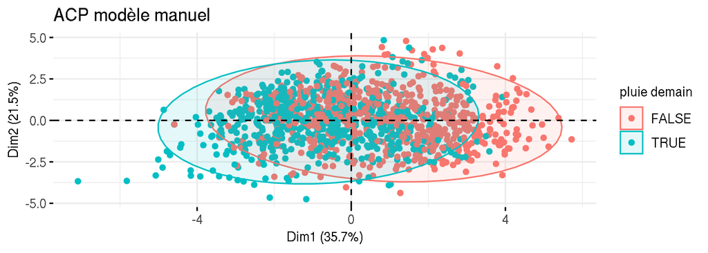

```r
  D = d[,(colnames(d) %in% n_perso) | colnames(d)=="pluie.demain"]
  res.pca = PCA(D,quali.sup = which(colnames(D)=="pluie.demain"),graph=FALSE)
  fviz_pca_ind (res.pca, geom.ind="point", col.ind=d$pluie.demain ,
                legend.title="pluie demain", addEllipses = T, title="ACP modèle manuel")
```

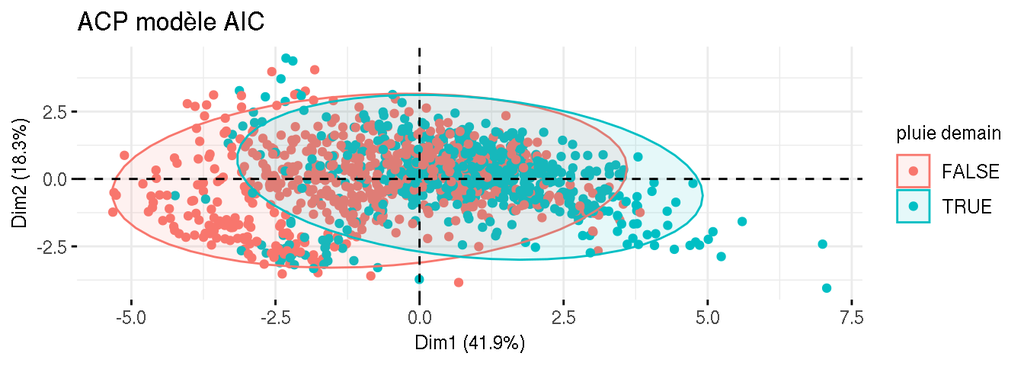

```r
  D = d[,(colnames(d) %in% n_AIC) | colnames(d)=="pluie.demain"]
  res.pca = PCA(D,quali.sup = which(colnames(D)=="pluie.demain"),graph=FALSE)
  fviz_pca_ind (res.pca, geom.ind="point", col.ind=d$pluie.demain ,
                legend.title="pluie demain", addEllipses = T, title="ACP modèle AIC")
```

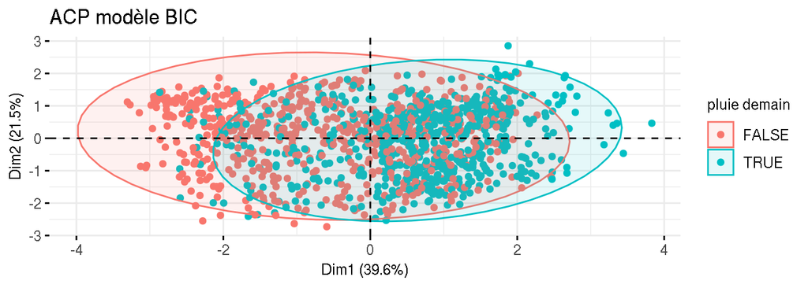

```r
  D = d[,(colnames(d) %in% n_BIC) | colnames(d)=="pluie.demain"]
  res.pca = PCA(D,quali.sup = which(colnames(D)=="pluie.demain"),graph=FALSE)
  fviz_pca_ind (res.pca, geom.ind="point", col.ind=d$pluie.demain ,
                legend.title="pluie demain", addEllipses = T, title="ACP modèle BIC")
```

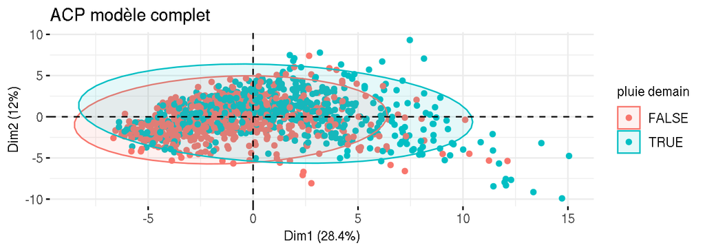

```r
  D = d
  res.pca = PCA(D,quali.sup = which(colnames(D)=="pluie.demain"),graph=FALSE)
  fviz_pca_ind (res.pca, geom.ind="point", col.ind=d$pluie.demain ,
                legend.title="pluie demain", addEllipses = T, title="ACP modèle complet")
```

# 6. Etude de performance par validation croisée

#### **6.1 Fonction pour faire la validation croisée**

**Métrique :** Pour ce calcul, on cherche a mesurer le taux d’erreur de prédiciction. On compare donc les vraies valeur de **pluie.demain** au arrondis des prédictions.

**Partitions :** Comme les données consécutives ont de la cohérence, on ne va pas les couper en K blocs consécutifs. A la place, pour le kieme bloc, on prend une ligne toutes les K lignes, en commencant par la kieme ligne.

**Critère de choix : MOYENNE des erreurs :** On choisira le modèle donnant le moins d’erreur moyenne sur la cross-validation. Les coefficients finaux seront donc la moyenne ponderée des coefficients de la validation croisèe. Le modèle contenant ces coefficient finaux est la seconde sortie de la fonction.

```r
  myCrossValidation = function(formule,dataFrame,nParts)
  {
    # Initialization
      errV = numeric(0)
    # Boucle for sur le nombre de parties
      for (k in 1:nParts)
      {
        # Calcul des indices du jeu de test
          indTest = seq(k,nrow(dataFrame),nParts)
          df_test = dataFrame[indTest,]
          df_train = dataFrame[-indTest,]
        # Calcul du modèle
          modele = glm(formule, family = binomial, data = df_train)
        # Calcul des coefficient du modèle final
          if (k==1)
            { MODEL = modele
              N_TRAIN = nrow(df_train)
              MODEL$coefficients = modele$coefficients*N_TRAIN
              N_SUM = N_TRAIN }
          else
            { N_TRAIN = nrow(df_train)
              MODEL$coefficients = MODEL$coefficients + modele$coefficients*N_TRAIN
              N_SUM = N_SUM + N_TRAIN }
        # Prédiction pour la validation crois
          pred = predict(modele, df_test, type = "response")
        # Calcul de l'erreur de prediction
          err = mean(abs(round(pred)-df_test$pluie.demain))
        # Ajout au vecteur
          errV = rbind(errV,err)
      }
    # Output
      MODEL$coefficients = MODEL$coefficients/N_SUM
      return(list(erreur = errV, modele = MODEL))
  }
```

#### **6.2 Application de la validation croisée avec 10 blocs**

```r
  cv_perso = myCrossValidation(f_perso, d, 10)
  cv_AIC   = myCrossValidation(f_AIC  , d, 10)
  cv_BIC   = myCrossValidation(f_BIC  , d, 10)
  cv_full  = myCrossValidation(pluie.demain ~ . , d, 10)
```

#### **6.3 Observation des résultats**

Voici l’ensemble des taux d’erreur pour les différentes méthodes

```r
  myResults = data.frame(cv_perso$erreur,cv_AIC$erreur,cv_BIC$erreur,cv_full$erreur)
  myResults
```

```
##       cv_perso.erreur cv_AIC.erreur cv_BIC.erreur cv_full.erreur
## err         0.3840000     0.3760000     0.3760000      0.3200000
## err.1       0.2960000     0.3280000     0.3120000      0.3040000
## err.2       0.3040000     0.3040000     0.2800000      0.3200000
## err.3       0.3760000     0.3440000     0.3680000      0.3600000
## err.4       0.3145161     0.3548387     0.3145161      0.3548387
## err.5       0.2903226     0.2903226     0.2580645      0.2419355
## err.6       0.2903226     0.2822581     0.2903226      0.2822581
## err.7       0.3225806     0.3306452     0.3225806      0.3387097
## err.8       0.2338710     0.2419355     0.2419355      0.2822581
## err.9       0.2500000     0.2661290     0.2419355      0.2580645
```

En observant les métriques ci-dessous, on choisit de retenir **le modèle BIC**. En effet, le **le modèle BIC** obtient la moyenne la plus faible avec **0.3005**

```r
  summary(myResults)
```

```
##  cv_perso.erreur  cv_AIC.erreur    cv_BIC.erreur    cv_full.erreur
##  Min.   :0.2339   Min.   :0.2419   Min.   :0.2419   Min.   :0.2419
##  1st Qu.:0.2903   1st Qu.:0.2843   1st Qu.:0.2635   1st Qu.:0.2823
##  Median :0.3000   Median :0.3160   Median :0.3012   Median :0.3120
##  Mean   :0.3062   Mean   :0.3118   Mean   :0.3005   Mean   :0.3062
##  3rd Qu.:0.3206   3rd Qu.:0.3407   3rd Qu.:0.3206   3rd Qu.:0.3340
##  Max.   :0.3840   Max.   :0.3760   Max.   :0.3760   Max.   :0.3600
```

# 7. Application du modèle retenu au jeu de test

- Lecture des données + création des features **mycosJD** et **mysinJD**.
- Prédiction avec le modèle moyenné **BIC** retenu.
- Nettoyage des features.
- Export du data frame dans le fichier **hardouin_meteo.predict.csv**.

```r
  # Lecture des données à prédire
    df_test = read.csv("meteo.test.csv")
  # Ajout de mycosJD et mysinJD
    tmp = do.call(paste, list(df_test$Month, df_test$Day, df_test$Year))
    tmp = as.Date(tmp, format=c("%m %d %Y"))
    df_test$mycosJD <- abs(cos(as.numeric(format(tmp, "%j"))/365*2*pi))
    df_test$mysinJD <- abs(sin(as.numeric(format(tmp, "%j"))/365*2*pi))
  # Prédiction
    prediction = round(predict(cv_BIC$modele, df_test, type = "response"))
  # Nettoyage
    df_test = df_test[,c("X","Year","Month","Day")]
    df_test$pluie.demain.prediction = prediction
  # Export
    write.csv(df_test,"hardouin_meteo.predict.csv")
```